# TaxonomyPhyloseqAnalyses

16S class

January 13, 2017

# Required packages

```r
library(phyloseq); packageVersion("phyloseq")
```

```
## [1] '1.19.1'
```

```r
library(ggplot2); packageVersion("ggplot2")
```

```
## [1] '2.2.1'
```

```r
library(dplyr); packageVersion("dplyr")
```

```
## [1] '0.5.0'
```

```r
library(gridExtra); packageVersion("gridExtra")
```

```
## [1] '2.2.1'
```

# Links

- http://benjjneb.github.io/dada2/assign.html#species-assignment
- The phyloseq website
  - https://joey711.github.io/phyloseq/

# Questions

- how dependent are the results on the training data (i.e. Silva or other database)?
- what allowMultiple should we use?

# Background

- minBoot: default = 50, is the minimum number out of 100 bootstraps that return the same genus (taxonomy) for a sequence so the sequence is assigned that taxonomy
- For human microbiome data and V4 sequencing, we typically see a bit under half of the abundant ribosomal sequence variants (RSVs) assigned unambiguously to species-level, and a bit under 2/3rds assigned ambiguously (ie. allowing multiple species assignment). This fraction drops off in less sampled environments and for rare RSVs.
  - **question is what is abundant here, but seems we have less**
- Results of richness estimates (for example) are probably unreliable, or wrong, if you have already trimmed low-abundance taxa from the data.

# Load seqtab and taxonomy data and source functions

```r
datapath <- "/Users/jvb740/MarieCurie_Work/BackgroundKnowledge/16S_Learning/DanFunD_243_maxEE-1"
load(file.path(datapath, "Dada_Data/DenoisedData.RData"))

load(file.path(datapath, "TaxAssign/TaxonomicData.RData"))

functionpath <- "."

source(file.path(functionpath, "Dada_TaxonomyFunctions.R"))
source(file.path(functionpath, "Dada_PlotFunctions.R"))

## At this point you should have seqtab and taxa.species
# NB: I had saved as taxa.80.species, in the current version you have directly taxa.species so the following 2 lines will not be necessary:
taxa.species <- taxa.80.species
rm(taxa.50, taxa.80, taxa.80.species, taxa.50.species, bimFs, bimRs, mergers, mergers.nochim)
```

# Look at Amplicon Distribution in seqtab (for later taxa filtering for example)

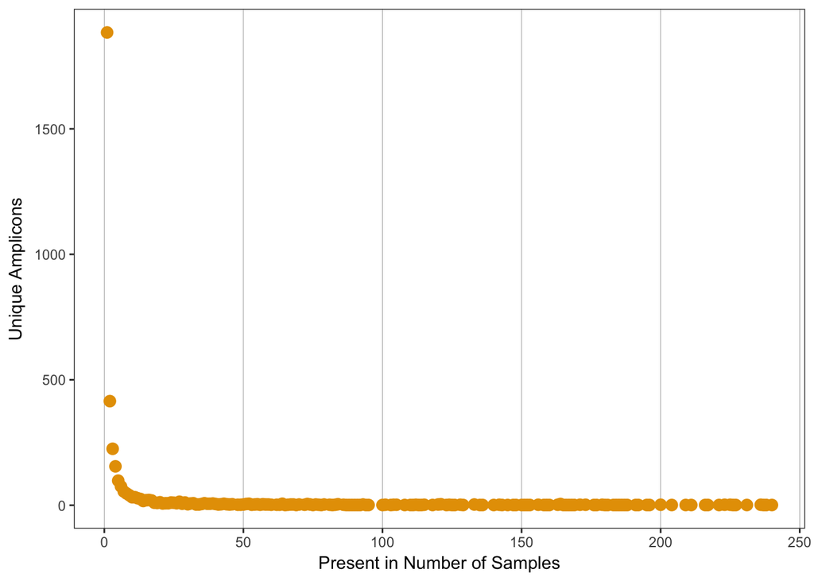

```r
TrList <- AmpliconDistribution(seqtab, PCentage = 15)

TrList[[1]]
```

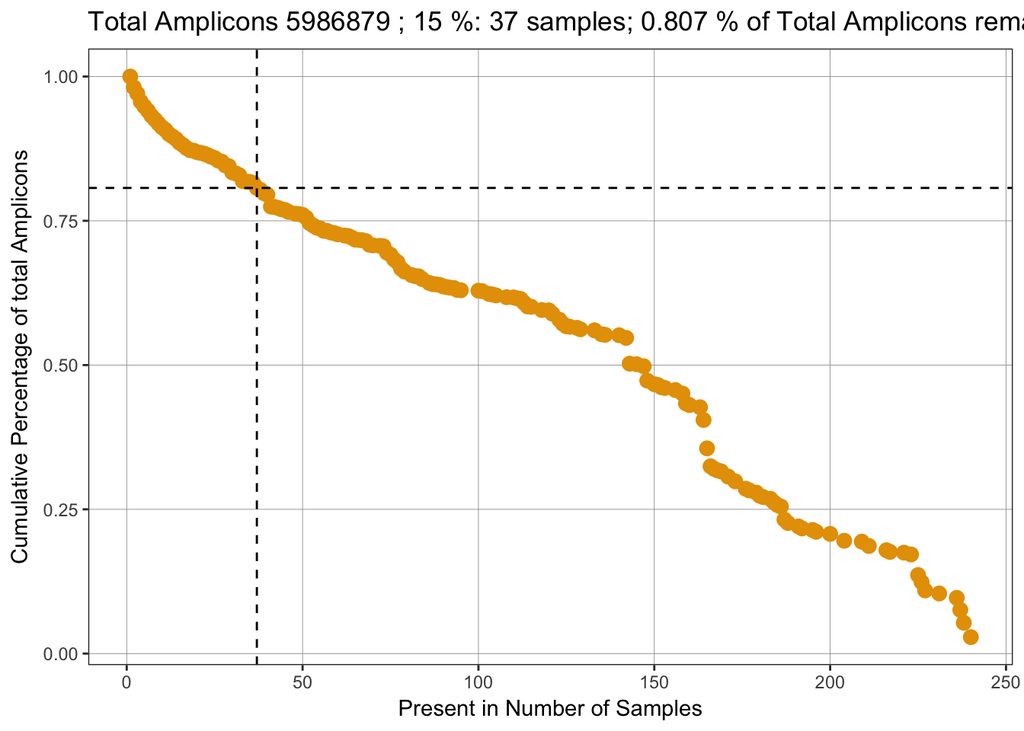

```r
TrList[[4]]
```

```r
# shows you for example that if you only keep the amplicons that were present in at least 15% of the samples you still keep over 80% of the amplicons
#TrList[[5]]

# SP <- "/Users/jvb740/MarieCurie_Work/TalksAndThoughts/170113_16SClass/Figures"
# pdf(file = file.path(SP, "AmpliconDistr2.pdf"), width = 7, height = 6)
# TrList[[4]]
# dev.off()
```

# Short Exploratory Analysis of the taxonomic assignment (taxa.species)

## Determine for each taxonomic level the percentage of sequences that could not be attributed unambiguously with the used minBoot

```r
# Number and percentage of assigned taxonomic levels for all amplicons
NAPerC <- NAPerCForTaxLevel(taxa.species)

NAPerC
```

```
##         CountNA       PerCNA CountNonNA  PerCNonNA
## Kingdom       1   0.02777778       3599  99.972222
## Phylum      186   5.16666667       3414  94.833333
## Class       250   6.94444444       3350  93.055556
## Order       283   7.86111111       3317  92.138889
## Family      630  17.50000000       2970  82.500000
## Genus      1512  42.00000000       2088  58.000000
## Species    3378  93.83333333        222   6.166667
## Total      3600 100.00000000       3600 100.000000
```

```r
# look at the Genus-species with multiple species assignment (at the first 5)
head(unname(taxa.species[grep(pattern = "/", taxa.species[,'Species']), c('Genus', 'Species')]), 5)
```

```
##      [,1]               [,2]
## [1,] "Faecalibacterium" "cf./prausnitzii"
## [2,] "Bacteroides"      "dorei/vulgatus"
## [3,] "Bifidobacterium"  "adolescentis/longum/stercoris"
## [4,] "Bacteroides"      "cellulosilyticus/timonensis"
## [5,] "Streptococcus"    "salivarius/thermophilus/vestibularis"
```

```r
# # # Number and percentage of assigned taxonomic levels related to the penetrance of the amplicons
# # TLvsPenetrance <- TaxLevelvsPenetrance(taxa = taxa.species, seqtab = seqtab)
#
# # Taxonomic assignments compared to the abundance of the sequences
# TLvsAb <- TaxLevelvsAbundance(taxa = taxa.species, seqtab = seqtab, Level = "Genus")
#
# TLvsAb[[2]]
# # could be done for other levels
```

- without removal of rare amplicons we get less than 10% of amplicons assigned to species levels
- Remember: For human microbiome data and V4 sequencing, we typically see a bit under half of the abundant ribosomal sequence variants (RSVs) assigned unambiguously to species-level, and a bit under 2/3rds assigned ambiguously (ie. allowing multiple species assignment). This fraction drops off in less sampled environments and for rare RSVs.
  - **question is what is abundant here, but seems we have less**

# Analyses in Phyloseq

## Generate the phyloseq object

```r
## NB: M
## Generate mock sample data
# sample_data in phyloseq is just a data.frame with rownames = Sample names where information on these samples is stored
# e.g
SampleNames <- rownames(seqtab)
Age <- sample(x = 20:70, size = length(SampleNames), replace = TRUE)
samdf <- data.frame(Sample = SampleNames, Age = Age)
samdf$Above50 <- Age > 50
rownames(samdf) <- SampleNames


# Generate the phyloseq file
ps <- phyloseq(otu_table(seqtab, taxa_are_rows=FALSE), tax_table(taxa.species), sample_data(samdf))
ps
```

```
## phyloseq-class experiment-level object
## otu_table()   OTU Table:         [ 3600 taxa and 243 samples ]
## sample_data() Sample Data:       [ 243 samples by 3 sample variables ]
## tax_table()   Taxonomy Table:    [ 3600 taxa by 7 taxonomic ranks ]
```

```r
# # some playing with phyloseq
# ntaxa(ps)
# nsamples(ps)
# sample_names(ps)
# sample_variables(ps)
# get_variable(ps, sample_variables(ps)[2])
# sample_data(ps)$Age
# rank_names(ps)
# colnames(tax_table(ps))
# get_taxa_unique(ps, "Phylum")
# sample_sums(ps)
# taxa_sums(ps) # abundance of the taxa over all samples (sum)
# get_taxa(ps, i = sample_names(ps)[1]) # so i = 1 refers to a sample
# get_sample(ps, taxa_names(ps)[1])
```

## Analyse **alpha-diversity** (especially Richness, Shannon, and Chao1)

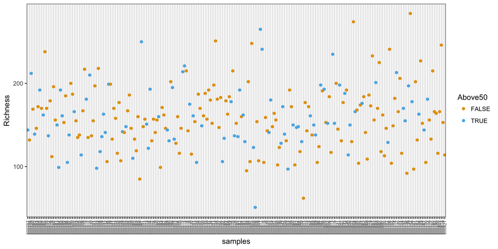

```r
## Get DataFrame with the alpha diversity measures
# NB: I use the estimate_richness function here (that is also used in plot_richness from phyloseq).
# all these alpha diversity measures are simple, see commented "Einschub/Insert" below
AlphaDiv <- estimate_richness(ps, measures = c("Shannon", "Chao1", "Observed"))
rownames(AlphaDiv) <- sample_names(ps)
# I prefer Richness over Observed
colnames(AlphaDiv)[colnames(AlphaDiv) == "Observed"] <- "Richness"

# ######################### Einschub/Insert  ##################
# calculating alpha diversity measures self and understanding estimate_richness better
# ## Understand the function complain:
# # it complains about missing singletons, which is the case when !any(otu_table(physeq) == 1) is TRUE

#### Richness, Chao1, ACE
# ## estimate_richness uses the estimateR function from the  vegan package
# AlphaMeasures <- vegan::estimateR(as(otu_table(ps), "matrix"))
# AlphaMeasures <- t(data.frame(AlphaMeasures))

## Richness:
# Richness <- rowSums(as(otu_table(ps), "matrix") != 0)

## Chao1:
# Chao1 makes use of singletons and doubletons see vignette of vegan package and maybe <http://www.coloss.org/beebook/I/gut-symbionts/2/2/4>
# we had no singletons, so here the same as richness
# se.chao1 is the standard error of the chao1
# here how to calculate chao1 yourself with singletons
# seqtab2 <- seqtab
# seqtab2[seqtab2 > 2 & seqtab2 < 10] <- 1 # introduce singletons
# Estimator <- ((rowSums(seqtab2 == 1))*((rowSums(seqtab2 == 1))-1))/(2*((rowSums(seqtab2 == 2))+1))
# Chao1 <- Richness+Estimator
# ## NB: the Variance (Standard Error) estimation is also given in the vignette but I was to lazy to do that here too
# I think Chao1 is pretty silly, isn't it?
#

### Shannon diversity, also simpson uses vegan::diversity function
# vegan::diversity(OTU, index = "shannon")

# ## Shannon self
# Basically just: $-sum(p_{i}*log(p_{i})$.
# # e.g.:
# STRA <- seqtab/rowSums(seqtab)
# STRA1 <- STRA*(-1)*(log(STRA))
# ShDiv <- rowSums(STRA1, na.rm = TRUE)
# identical(ShDiv, vegan::diversity(seqtab, index = "shannon")) # TRUE!

# ## Simpson would be easy
# Simpson <- vegan::diversity(seqtab, index = "simpson")
# STRA2 <- STRA*STRA
# SimDiv <- 1-rowSums(STRA2, na.rm = TRUE)
# identical(Simpson, SimDiv) # TRUE
#
# ###### Ende Einschub/ End Insert ##########################################


## Illustrate alpha diversity measures
## I use plotAlphaDiversity function which is related to plot_richness from phyloseq (but also offers boxplots and
# always renders each plot individually in a list instead of using facet_wraps)

TrList <- plotAlphaDiversity(ps, x = "samples", measures = c("Observed", "Shannon", "Chao1"), color = "Above50")

# alternatively List of Boxplots using group
TrListBP <- plotAlphaDiversity(ps, x = "Above50", color = "Above50", group = "Above50", measures = c("Observed", "Shannon", "Chao1"))

TrList[[1]]
```

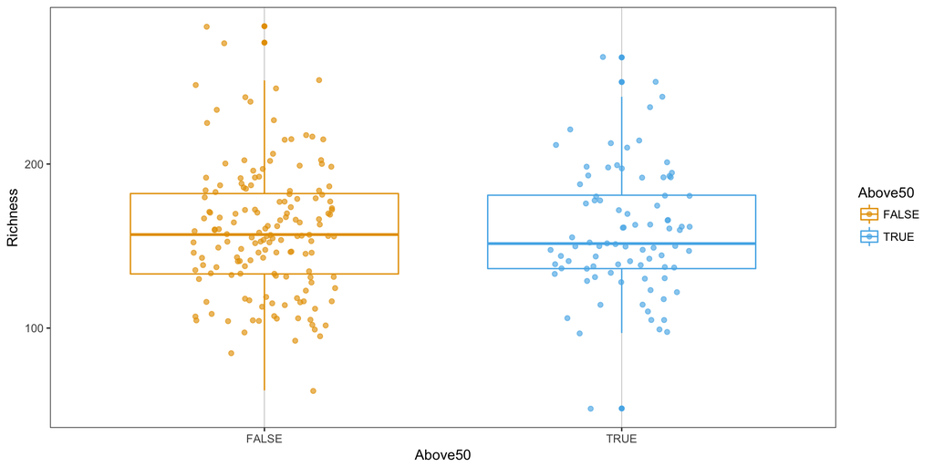

```r
TrListBP[[1]]
```

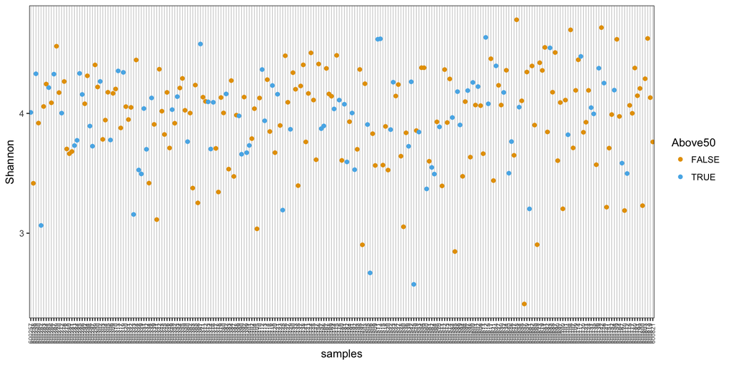

```r
TrList[[3]]
```

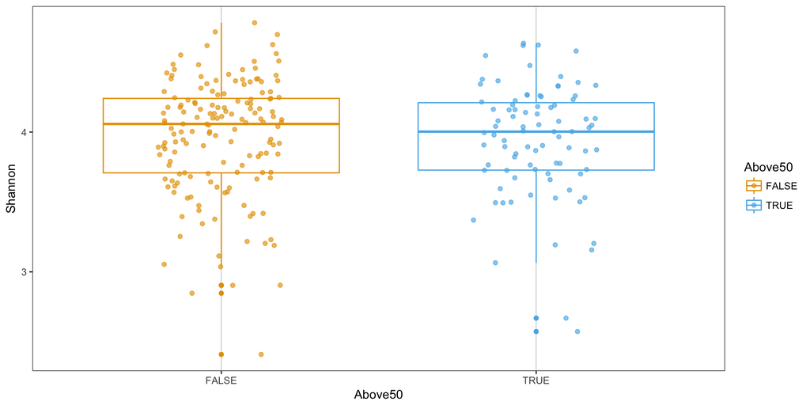

```r
TrListBP[[3]]
```

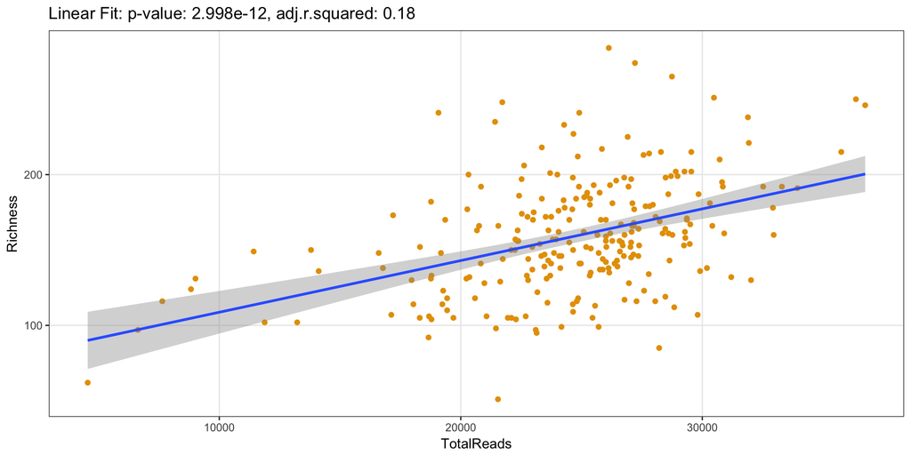

```r
#### Plot possible correlation between alpha diversity measures and sequencing depth

TrListLm <- plotAlphaDivVsSeqDepth(physeq = ps, measures = c("Observed", "Shannon", "Chao1"))


TrListLm[[1]]
```

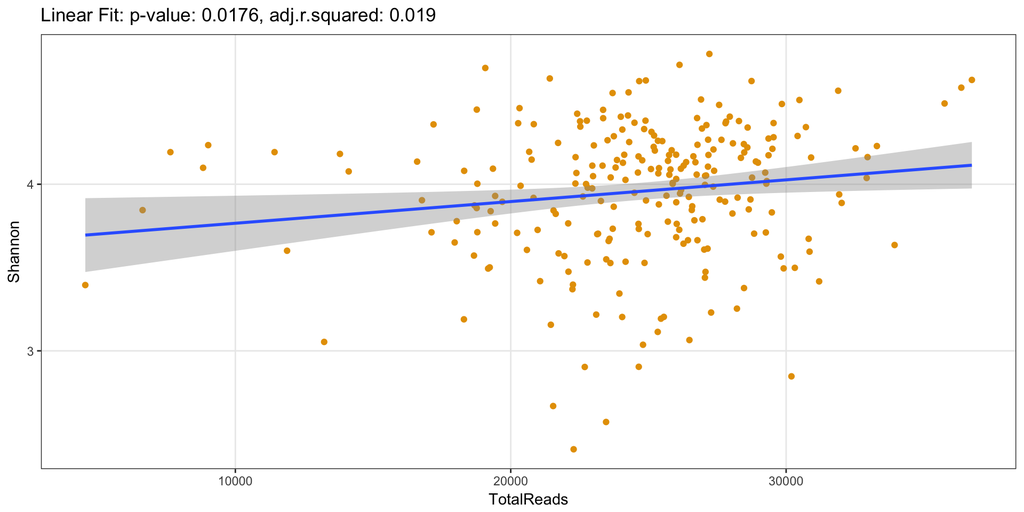

```r
TrListLm[[3]]
```

## beta diversity (distances between samples) and ordination plots (e.g. PCoA)

### With Global Patterns example data

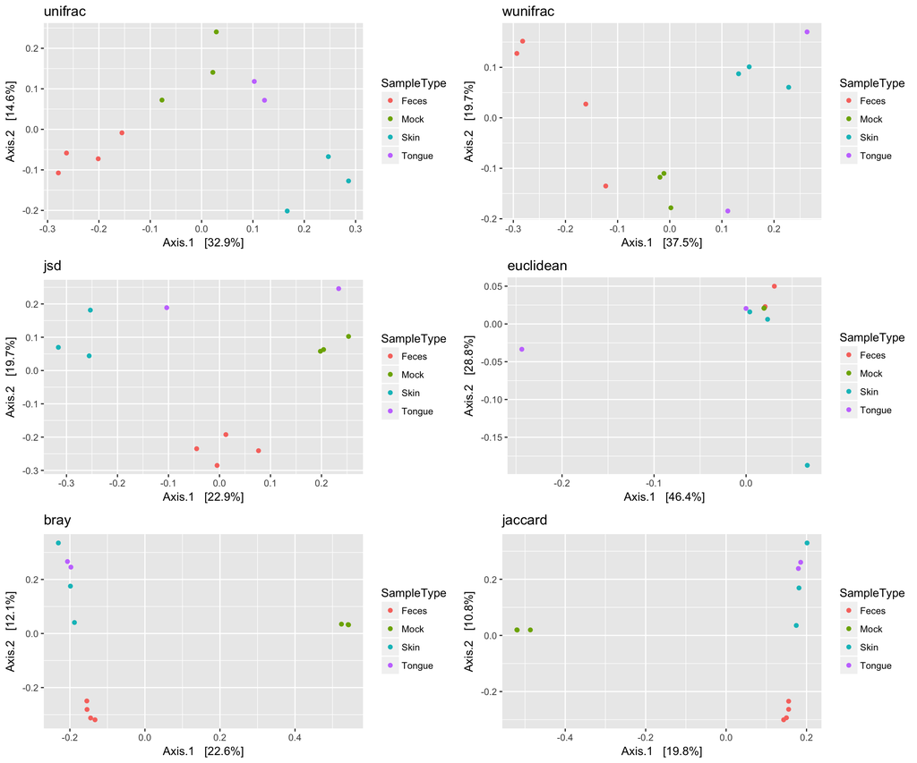

```r
# ------------- prepare the data --------------
## example physeq
data(GlobalPatterns)
GP <- GlobalPatterns
# ntaxa(GP) # 19216

## Filtering the GP to reduce processing time
# keep only human samples
sample_data(GP)$human = factor( get_variable(GP, "SampleType") %in% c("Feces", "Mock", "Skin", "Tongue") )

GPh <- subset_samples(GP, subset = human == TRUE )

## keep only taxa present in at least 30% of samples
GPhf <- filter_taxa(GPh, function(x){sum(x != 0) > .3*length(x)}, prune = TRUE) # still 3670 taxa

## do their normalisation
total = median(sample_sums(GPhf))
standf = function(x, t=total) round(t * (x / sum(x)))
GPhfs = transform_sample_counts(GPhf, standf)
#range(sample_sums(GPhfs))

## change to relative abundance here
GPhfs = transform_sample_counts(GPhfs, function(x){x/sum(x)})

## keep only taxa with good variation
GPhfsf = filter_taxa(GPhfs, function(x) sd(x)/mean(x) > 3.0, prune = TRUE) # down to 388 taxa
# sample_sums(GPhfsf) # again very different but I think fine since all have now same taxa

# ------------- Calculate distances between samples with different measures (phyloseq::distance) -------
dist_methods <- unlist(distanceMethodList)
# I reduce to
dist_methods <- dist_methods[dist_methods %in% c("unifrac", "wunifrac", "jsd", "bray", "jaccard", "euclidean")]

Distlist <- vector("list", length(dist_methods))
names(Distlist) = dist_methods

for( i in dist_methods ){
        # Calculate distance matrix
        iDist <- phyloseq::distance(GPhfsf, method=i)
        Distlist[[i]] = iDist
}


# ========= recapitulate Bray Crutis Distance ==========
# physeq <- GPhfsf
# if(taxa_are_rows(physeq)){
#         DF <- as(otu_table(physeq), "matrix")
# } else {
#         DF <- as(t(otu_table(physeq)), "matrix")
# }
#
# ## Long way (computationally) with apply and sapply:
# BrayDistMatrix <- sapply(1:ncol(DF), function(y){apply(DF, 2, function(x){ sum(abs(x-DF[,y]))/sum(x + DF[,y]) })})
# colnames(BrayDistMatrix) <- rownames(BrayDistMatrix)
# # compare:
# all.equal(as(Distlist[["bray"]], "matrix"), BrayDistMatrix, check.attributes = FALSE) # TRUE

# --------------------- Ordination Plots: PCoA and NMDS ----------------------

PCoAList <- vector("list", length(dist_methods))
PCoAPlotList <- vector("list", length(dist_methods))
NMDSList <- vector("list", length(dist_methods))
NMDSPlotList <- vector("list", length(dist_methods))

for (i in seq_along(dist_methods)) {

        PCoAList[[i]] <- ordinate(GPhfsf, "PCoA", distance=Distlist[[i]])
        #NMDSList[[i]] <- ordinate(GPhfsf, "NMDS", distance=Distlist[[i]])
        PCoAPlotList[[i]] <- plot_ordination(GPhfsf, PCoAList[[i]], color="SampleType") + ggtitle(names(Distlist)[i])
        #NMDSPlotList[[i]] <- plot_ordination(GPhfsf, NMDSList[[i]], color="SampleType") + ggtitle(names(Distlist)[i])
}
names(PCoAList) <- names(NMDSList) <- names(PCoAPlotList) <- names(NMDSPlotList) <- names(Distlist)

do.call("grid.arrange", c(PCoAPlotList, ncol = 2))
```

```r
# do.call("grid.arrange", c(NMDSPlotList, ncol = 2))
```

## Bar plots

```r
# example of using only the taxa that are present in at least 2 samples
# Above2Taxa <- taxa_names(ps)[colSums(otu_table(ps) != 0) > 1]
# psTop <- transform_sample_counts(ps, function(OTU) OTU/sum(OTU)) # change to relative Abundances here
# psTop = prune_taxa(Above2Taxa, psTop)
# sample_sums(psTop) # NOTE if you do it this way around: the relative abundances do not sum to 1
# plot_bar(psTop, x="Sample", fill="Family")
# plot_bar(psTop, x="Sample", fill="Phylum")
#
# psTop2 = prune_taxa(Above2Taxa, ps)
# psTop2 <- transform_sample_counts(psTop2, function(OTU) OTU/sum(OTU)) # change to relative Abundances here
# sample_sums(psTop2) # sum to 1
# plot_bar(psTop2, x="Sample", fill="Family")
# plot_bar(psTop2, x="Sample", fill="Phylum")
```